# Survey II Final Project

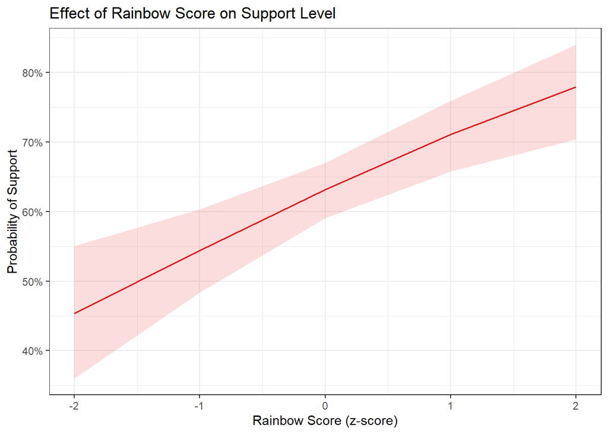

```r
p3
```

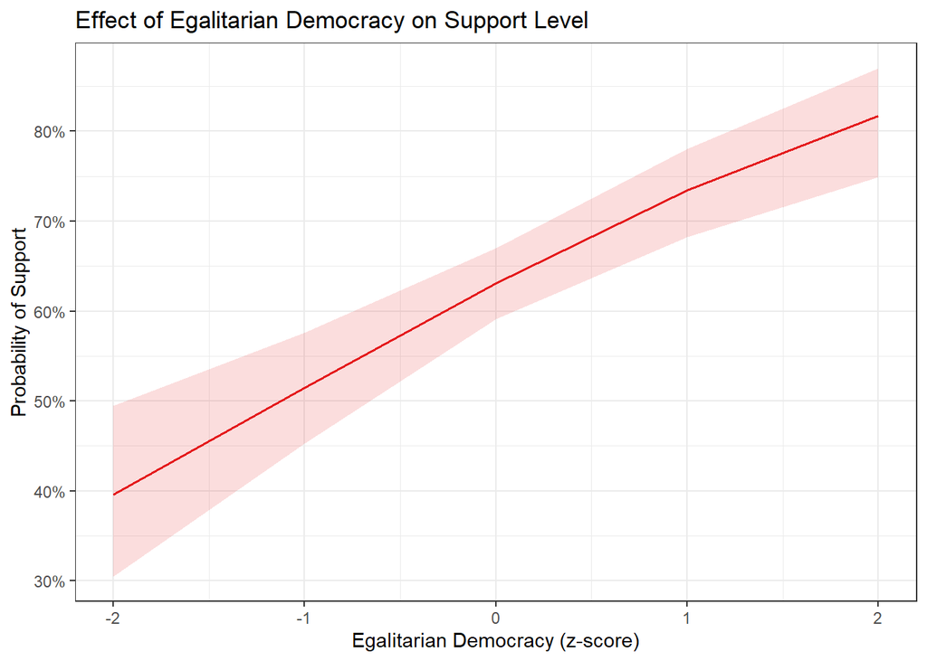

```r
p4
```

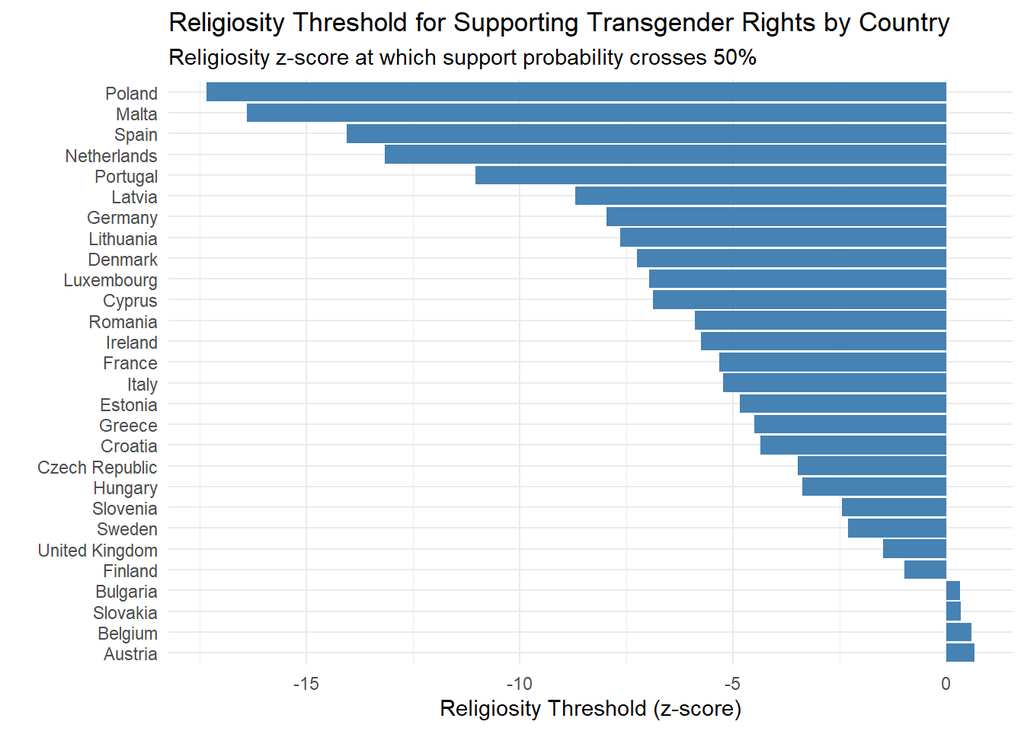

```r
p5
```

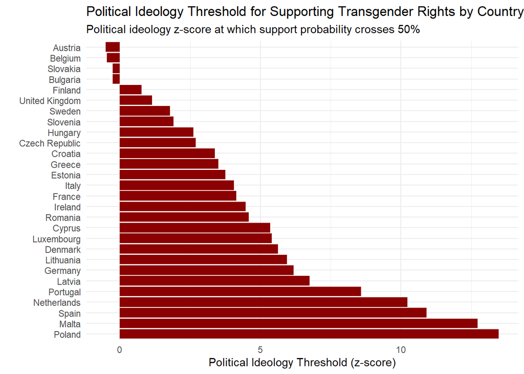

```r
p6
```

## Predictive Modelling

### Data

```r
# Reading data set that was already prepared for the ML training
data <- read_rds("R/data_for_ML.rds")
data$qc19 <- as.factor(data$qc19)
```

### Train Model

```r
# Training Data Split
set.seed(3147)
trainIndex <- createDataPartition(data$qc19, p=0.7,
                             list = FALSE,
                             times = 1)
train <- data[trainIndex,]
test <- data[-trainIndex,]
```

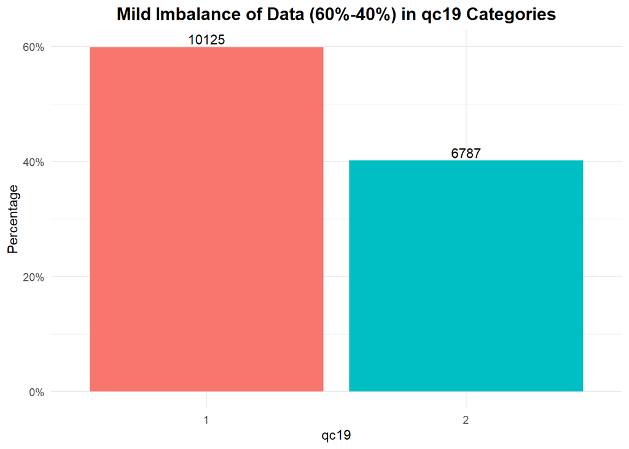

```r
# Data Imbalance Check
train %>%
  mutate(isocntry = ifelse(isocntry %in% c("DE-W", "DE-E"), "DE", isocntry)) %>%
  group_by(qc19) %>%
  summarise(count = n()) %>%
  mutate(percent = count/sum(count)) %>%
  arrange(desc(percent)) %>%
  ungroup() %>%
  ggplot(aes(x= qc19, y=percent, label=count, fill = qc19)) +
  geom_col() +
  geom_text(vjust = -0.3) +
  scale_y_continuous(labels=scales::percent) +
  theme_minimal() +
  labs(y = "Percentage", x = "qc19",
       title = "Mild Imbalance of Data (60%-40%) in qc19 Categories") +
  theme(plot.title = element_text(hjust = 0.5, face = "bold", size = 14),
        legend.position = "none")
```

There is some degree of imbalance in the data for our targeted variable. We will apply all 3 balancing techniques (Undersampling, Oversampling, and Synthetic Data) during resampling.

```r
# Elastic Net Dimension Reduction

# set.seed(3244)
# # Training control
# ctrl <- trainControl(method = "repeatedcv",
#                      number=5,
#                      repeats = 5,
#                      search = "random",
#                      verboseIter = TRUE)
# # Train model
# enet <- train(qc19 ~., data = train, method="glmnet",
#               ppreProcess = c("center", "scale"),
#               tuneLength = 10,
#               trControl = ctrl)
# saveRDS(enet, "regularization/elasticNet.rds")

# # Columns with coef = 0
# enet_coefs <- coef(enet$finalModel, enet$bestTune$lambda) %>%
#   unlist() %>%
#   as.matrix() %>%
#   as.data.frame()
#
# select_features_enet <- enet_coefs %>%
#   filter(s1 != 0) %>%
#   row.names() %>%
#   .[-1]
#
# select_features_enet

#-------------------------------------------------------------------
# Feature Selection

# # Mapping enet
# select <- c()
# for (i in colnames(train %>% select_if(is.character))) {
#   if (sum(grepl(i, select_features_enet)) >0) {
#     select <- c(select,i)
#   }
# }
#
# train_enet <- train %>%
#   select(any_of(c(select_features_enet, select, "qc19"))) %>%
#   mutate_if(is.character, as.factor) %>%
#   mutate(qc19 = as.factor(qc19))

train_enet <- read_rds("R/regularization/enet_training_data.rds")
```

As the regularization takes a long time to load, we saved dataset with already selected features after Elastic Net feature reduction so it is readily available.

```r
# Control set
# ctrl <- trainControl(method = "repeatedcv", number=5,
                     # repeats = 5, verboseIter = TRUE)

#-------------------------------------------------------------------
# Random Forest (RF)

# ## under
# ctrl$sampling <- "down"
# rf_enet_under <- train(
#   qc19 ~ .,
#   data = train_enet,
#   method = "rf",
#   trControl = ctrl
# )
# saveRDS(rf_enet_under, file = "models/rf_enet_under.rds")
#
# ## upper
# ctrl$sampling <- "up"
# rf_enet_upper <- train(
#   qc19 ~ .,
#   data = train_enet,
#   method = "rf",
#   trControl = ctrl
# )
# saveRDS(rf_enet_upper, file = "models/rf_enet_upper.rds")
#
# ## synthetic
# ctrl$sampling <- "smote"
# rf_enet_smote <- train(
#   qc19 ~ .,
#   data = train_enet,
#   method = "rf",
#   trControl = ctrl
# )
# saveRDS(rf_enet_smote, file = "models/rf_enet_smote.rds")

#-------------------------------------------------------------------
# Gradient Boosting Machines (GBM)

# ## under
# ctrl$sampling <- "down"
# gbm_enet_under <- train(
#   qc19 ~ .,
#   data = train_enet,
#   method = "gbm",
#   trControl = ctrl
# )
# saveRDS(gbm_enet_under, file = "models/gbm_enet_under.rds")
#
# ## upper
# ctrl$sampling <- "up"
# gbm_enet_upper <- train(
#   qc19 ~ .,
#   data = train_enet,
#   method = "gbm",
#   trControl = ctrl
# )
# saveRDS(gbm_enet_upper, file = "models/gbm_enet_upper.rds")
#
# ## synthetic
# ctrl$sampling <- "smote"
# gbm_enet_smote <- train(
#   qc19 ~ .,
#   data = train_enet,
#   method = "gbm",
#   trControl = ctrl
# )
# saveRDS(gbm_enet_smote, file = "models/gbm_enet_smote.rds")

#-------------------------------------------------------------------
# Support Vector Machine (SVM)

# ## under
# ctrl$sampling <- "down"
# svm_enet_under <- train(
#   qc19 ~ .,
#   data = train_enet,
#   method = "svmRadial",
#   trControl = ctrl
# )
# saveRDS(svm_enet_under, file = "models/svm_enet_under.rds")
#
# ## upper
# ctrl$sampling <- "up"
# svm_enet_upper <- train(
#   qc19 ~ .,
#   data = train_enet,
#   method = "svmRadial",
#   trControl = ctrl
# )
# saveRDS(svm_enet_upper, file = "models/svm_enet_upper.rds")
#
# ## synthetic
# ctrl$sampling <- "smote"
# svm_enet_smote <- train(
#   qc19 ~ .,
#   data = train_enet,
#   method = "svmRadial",
#   trControl = ctrl
# )
# saveRDS(svm_enet_smote, file = "models/svm_enet_smote.rds")
```

Similarly, these models take a long time to train. Therefore, we will only load the pre-trained models using this code.

### Performance Evaluation

*Note: due to time constraint, we were only able to train 7 models.

```r
# Performance on training data

# Random Forest
rf_under <- read_rds("R/models/rf_enet_under.rds")
#rf_over <- read_rds("R/models/rf_enet_upper.rds")
rf_smote <- read_rds("R/models/rf_enet_smote.rds")

# Gradient Boosting Machines
gbm_under <- read_rds("R/models/gbm_enet_under.rds")
gbm_over <- read_rds("R/models/gbm_enet_upper.rds")
gbm_smote <- read_rds("R/models/gbm_enet_smote.rds")


# Support Vector Machine
svm_under <- read_rds("R/models/svm_enet_under.rds")
svm_over <- read_rds("R/models/svm_enet_upper.rds")
# svm_smote <- read_rds("R/models/svm_enet_smote.rds")

#-------------------------------------------------------------------
# Summarizing performance of all models in training data
results_train <- resamples(list(
  rf_u = rf_under,
  # rf_o = rf_over,
  rf_s =  rf_smote,
  gbm_u = gbm_under,
  gbm_o = gbm_over,
  gbm_s = gbm_smote,
  svm_o = svm_over,
  # svm_s = svm_smote,
  svm_u = svm_under
  ))

summary(results_train)
```

```
##
## Call:
## summary.resamples(object = results_train)
##
## Models: rf_u, rf_s, gbm_u, gbm_o, gbm_s, svm_o, svm_u
## Number of resamples: 25
##
## Accuracy
##            Min.   1st Qu.    Median      Mean   3rd Qu.      Max. NA's
## rf_u  0.8220514 0.8347620 0.8373743 0.8370034 0.8394441 0.8495418    0
## rf_s  0.8335305 0.8412651 0.8441750 0.8438979 0.8459491 0.8554110    0
## gbm_u 0.8264341 0.8311650 0.8358959 0.8353360 0.8385571 0.8450621    0
## gbm_o 0.8211118 0.8302779 0.8329391 0.8339519 0.8364873 0.8471771    0
## gbm_s 0.8237729 0.8338261 0.8389004 0.8394276 0.8453578 0.8533846    0
## svm_o 0.8089888 0.8205735 0.8235294 0.8252841 0.8308693 0.8406268    0
## svm_u 0.7971614 0.8184506 0.8214602 0.8228354 0.8282589 0.8415607    0
##
## Kappa
##            Min.   1st Qu.    Median      Mean   3rd Qu.      Max. NA's
## rf_u  0.6367569 0.6611306 0.6683965 0.6675539 0.6731816 0.6926166    0
## rf_s  0.6524888 0.6702101 0.6772795 0.6760236 0.6806980 0.7010085    0
## gbm_u 0.6440114 0.6545422 0.6621228 0.6623099 0.6678600 0.6818750    0
## gbm_o 0.6323906 0.6537616 0.6576900 0.6593744 0.6646308 0.6882308    0
## gbm_s 0.6327911 0.6545511 0.6648100 0.6657489 0.6780423 0.6944647    0
## svm_o 0.6124550 0.6346527 0.6399256 0.6442347 0.6550766 0.6749899    0
## svm_u 0.5859069 0.6288976 0.6365316 0.6385744 0.6493067 0.6764269    0
```

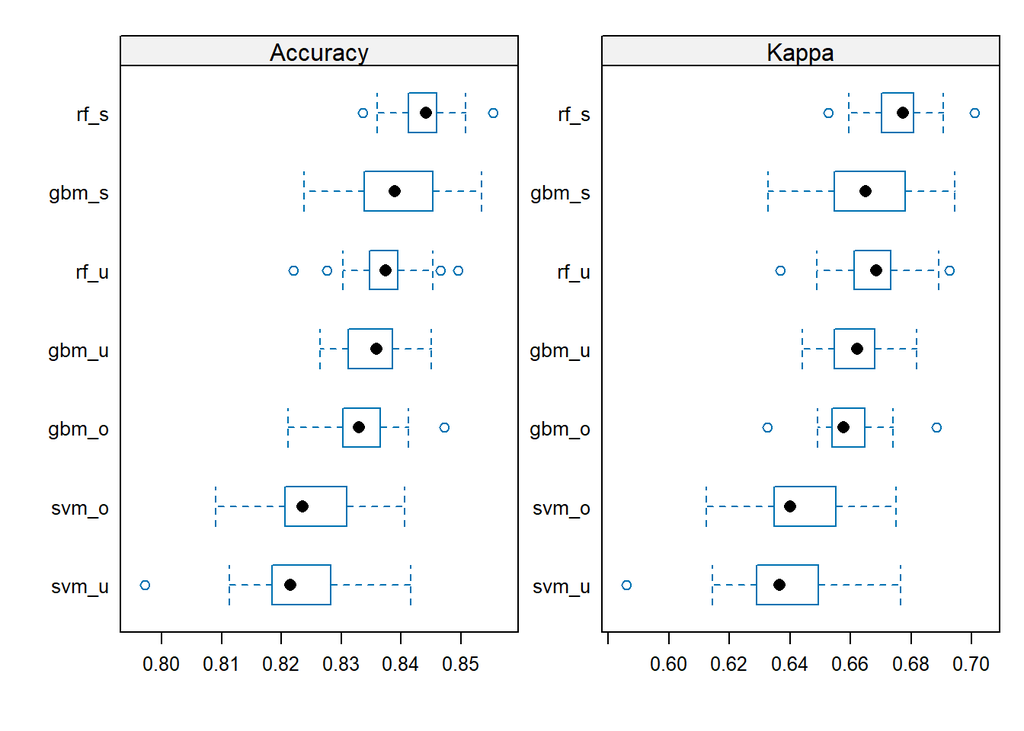

```r
bwplot(results_train, scales = list(x = list(relation = "free"), y = list(relation = "free")))
```

Random Forest model trained with synthetic data generation seems to be the best-performing model on training dataset. We will evaluate again the performance of the models on testing set.

```r
# Prediction on individual level

test <- test %>%
  mutate(qc19 = as.factor(qc19))

# Random Forest
p_rf_u <- predict(rf_under, test)
# p_rf_o <- predict(rf_over, test)
p_rf_s <- predict(rf_smote, test)

# Gradient Boosting Machines
p_gbm_u <- predict(gbm_under, test)
p_gbm_o <- predict(gbm_over, test)
p_gbm_s <- predict(gbm_smote, test)

# Support Vector Machine
p_svm_u <- predict(svm_under, test)
p_svm_o <- predict(svm_over, test)
# p_svm_s <- predict(svm_smote, test)

p_list <- list(rf_u = p_rf_u,
            # rf_o = p_rf_o,
            rf_s = p_rf_s,
            gbm_u = p_gbm_u,
            gbm_o = p_gbm_o,
            gbm_s = p_gbm_s,
            #svm_s = p_svm_s,
            svm_o = p_svm_o,
            svm_u = p_svm_u
            )

#-------------------------------------------------------------------
# Create a dataframe of the model's performance
cMatrix <- as.data.frame(list(
  Model = NA,
  Accuracy = NA,
  Kappy = NA
))

for (i in 1:length(p_list)) {
  model <- names(p_list[i])
  pred <- p_list[i] %>% unlist()
  matrix <- confusionMatrix(pred, test$qc19)$overall[1:2]
 cMatrix <- rbind(cMatrix, c(model, matrix))
}

cMatrix <- cMatrix %>%
  drop_na()

#-------------------------------------------------------------------
# Top 3 best-performing models
cMatrix %>% slice_max(Accuracy, n = 3)
```

```
##   Model          Accuracy             Kappy
## 1  rf_s 0.850400220811482 0.689660262423919
## 2 gbm_s 0.843637869169197 0.674694628409652
## 3 gbm_u  0.84115373999448 0.674324463529235
```

The Random Forest with synthetic data balancing performs the best on the testing, even with slightly better performance than in the training set. We, therefore, will use it as the model for prediction.

```r
# Prediction on country level

country_comp <- test            # replicate test set
country_comp$pred <- p_rf_s    # create new column of predictions from Random Forest (using synthetic data generation)

#------------------------------------------------------------------------
# Summarizing real support level of countries
country_original <- country_comp %>%
  group_by(isocntry, qc19) %>%
  summarise(count = n()) %>%
  group_by(isocntry) %>%
  mutate(pcg = count/sum(count))
# Summarizing predicted support level of countries
country_pred <- country_comp %>%
  group_by(isocntry, pred) %>%
  summarise(count = n()) %>%
  group_by(isocntry) %>%
  mutate(pcg = count/sum(count))
# Joining the previous 2 summarized dataframes
comparison <- cbind(select(country_original, c(isocntry,qc19, pcg)), country_pred$pcg) %>%
  rename("response" = 2,
         "original" = 3,
         "pred" = 4) %>%
  mutate(response = factor(c("1", "2"), levels = c("2", "1"))) %>%
  pivot_longer(cols = c("original", "pred"), names_to = "type") %>%
  mutate(type = factor(type, labels = c("Original Responses", "Predicted Responses")))
```

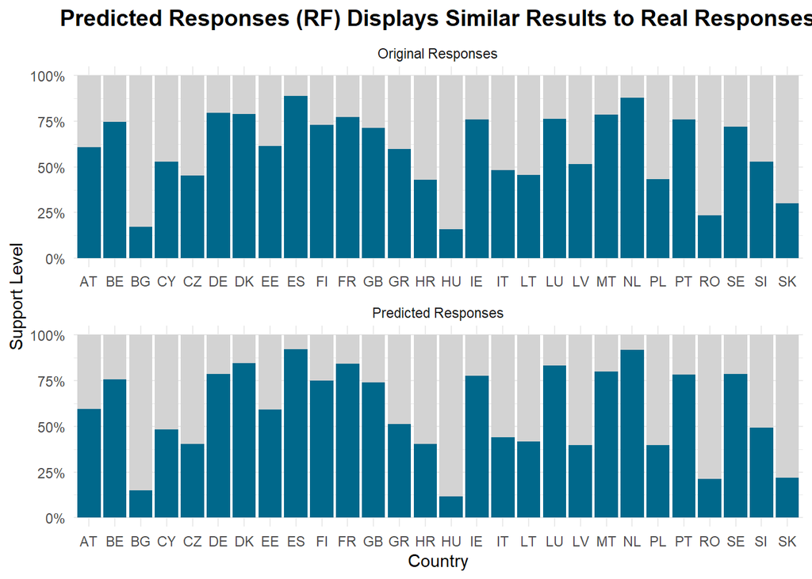

```r
#-----------------------------------------------------------------------------
# Visualization of both predicted and original support levels among countries
ggplot(comparison, aes(x= reorder(isocntry, value), y=value, fill=response)) +
  geom_bar(position="stack", stat="identity") +
  theme_minimal() +
  scale_y_continuous(labels = scales::percent) +
  scale_fill_manual( values = c("lightgrey", "deepskyblue4")) +
  facet_wrap(~type, nrow = 2, scales = "free") +
  labs(x = "Country", y = "Support Level",
       title = "Predicted Responses (RF) Displays Similar Results to Real Responses") +
  theme(legend.position = "none",
        plot.title = element_text(hjust = 0.5, face = "bold", size = 14))
```

We can see that on a country level, the predictions from our models are quite accurate and reflects well the support level of the real dataset.

### Filling The Gap

```r
# Loading original full dataset (without removing DK answers)
qc19_uniterated <- read_rds("df_rf_enriched.rds") %>% select(qc19) %>% pull()
full_data <- read_rds("df_rf_enriched_new.rds") %>%
  select(-1)
full_data$qc19 <- qc19_uniterated

full_pred <- predict(rf_smote, full_data) # Prediction using RF synthetic data
full_data$pred <- full_pred                # Create new column of the prediction

# Replace DK answers with predicted data
full_data <- full_data %>%
  mutate(qc19_enhanced = ifelse(qc19 == 3, pred, qc19))

#-----------------------------------------------------------------------------
# (Enhanced) Summarize data by country
sum_enhanced <- full_data %>%
  group_by(isocntry, qc19_enhanced) %>%
  summarise(count = n()) %>%
  group_by(isocntry) %>%
  mutate(pcg = count/sum(count))
# (Enhanced) Ranking of countries list
sort_enhanced <- sum_enhanced%>%
  filter(qc19_enhanced == 1) %>%
  arrange(desc(pcg)) %>%
  pull(isocntry)

# (Original) Summarize data by country
sum_origin <- full_data %>%
  group_by(isocntry, qc19) %>%
  summarise(count = n()) %>%
  group_by(isocntry) %>%
  mutate(pcg = count/sum(count))
```

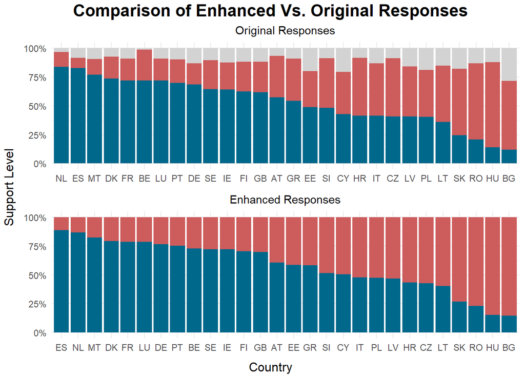

```r
# (Original) Ranking of countries list
sort_origin <- sum_origin%>%
  filter(qc19 == 1) %>%
  arrange(desc(pcg)) %>%
  pull(isocntry)

#-----------------------------------------------------------------------------
# Visualization of support level with predicted answers of DK responses
g_enhanced <- ggplot(sum_enhanced,
                     aes(x=factor(isocntry, sort_enhanced), y=count, fill = factor(qc19_enhanced, levels = c("2", "1")))) +
  geom_bar(position="fill", stat="identity") +
    theme_minimal() +
  scale_y_continuous(labels = scales::percent) +
  scale_fill_manual( values = c("indianred", "deepskyblue4")) +
  labs(x = "Country", y = "Support Level",
       title = "Enhanced Responses") +
  theme(legend.position = "none",
        plot.title = element_text(hjust = 0.5, size = 11),
        axis.title = element_blank())

g_origin <- ggplot(sum_origin,
                     aes(x=factor(isocntry, sort_origin), y=count, fill = factor(qc19, levels = c("3","2", "1")))) +
  geom_bar(position="fill", stat="identity") +
    theme_minimal() +
  scale_y_continuous(labels = scales::percent) +
  scale_fill_manual( values = c("lightgrey", "indianred", "deepskyblue4")) +
  labs(x = "", y = "Support Level",
       title = "Original Responses") +
  theme(legend.position = "none",
        plot.title = element_text(hjust = 0.5, size = 11),
        axis.title = element_blank())

library(ggpubr)
ggarrange(g_origin, g_enhanced,
                  nrow = 2) %>%
  annotate_figure(top = text_grob("Comparison of Enhanced Vs. Original Responses", face = "bold", size = 16, hjust=0.5),
                  left = text_grob("Support Level", rot = 90),
                  bottom = text_grob("Country"))
```

With the trained model, we filled in the surveys that answered “DK” and estimated a better picture of the support level of all the countries. The ranking are close to original ranking with some little movement of positions. Spain is estimated to have the highest level of support instead of the Netherlands while Czech Republic is expected to have less support overall if all respondents gave a “Yes” or “No” answer to question qc19.